# Feature Engineering & EDA

Yiheng Shen ys3323

```python
# import packages
import numpy as np
import pandas as pd
import seaborn as sns
import matplotlib.pyplot as plt
import plotly
import plotly.express as px
import calendar
```

## Load Data

```python
# load data & take a glance
df = pd.read_csv('purchase_credit_card.csv')
df.head(2)
```

|  | Year-Month | Agency Number | Agency Name | Cardholder Last Name | Cardholder First Initial | Description | Amount | Vendor | Transaction Date | Posted Date | Merchant Category Code (MCC) |
| --- | --- | --- | --- | --- | --- | --- | --- | --- | --- | --- | --- |
| 0 | 201307 | 1000 | OKLAHOMA STATE UNIVERSITY | Mason | C | GENERAL PURCHASE | 890.00 | NACAS | 07/30/2013 12:00:00 AM | 07/31/2013 12:00:00 AM | CHARITABLE AND SOCIAL SERVICE ORGANIZATIONS |
| 1 | 201307 | 1000 | OKLAHOMA STATE UNIVERSITY | Mason | C | ROOM CHARGES | 368.96 | SHERATON HOTEL | 07/30/2013 12:00:00 AM | 07/31/2013 12:00:00 AM | SHERATON |

```python
# glimpse of the dataset
#df.info()
```

#### CheckPoint 1

- No Missing values, good for EDA
- Agency number and agency name are together identical, no need for EDA twice
- card holder names may duplicate, only EDA for combinations of columns

## (1) Raw Features: Check the Distribution of Each Columns

### Feature 1: Year-Month

```python
# categorize and count Year-Month
df['Year-Month'] = df['Year-Month'].astype('category')
df['Year-Month'].value_counts()
```

```
201310    40266
201308    39314
201404    39249
201309    38762
201403    38188
201406    37955
201307    37635
201401    37230
201405    36784
201402    35831
201311    34275
201312    26969
Name: Year-Month, dtype: int64
```

- basically evenly distributed

### Feature 2: Agency Name

```python
# Summarize the count statistics by agency_name in df_count
df_count = df['Agency Name'].value_counts()
df_count = pd.DataFrame(df_count).reset_index()
df_count.columns = ['Agency Name','Count']

fig = px.bar(df_count, x='Agency Name', y='Count', color = 'Agency Name', width=1000, height=400)
fig.show()
```

[interactive chart not shown]

- OKLAHOMA STATE UNIVERSITY has the largest number of transactions and UNIVERSITY OF OKLAHOMA has the second place

### Feature 3: Description

```python
# count of Description
df['Description'].value_counts()
```

```
GENERAL PURCHASE                                      247187
AIR TRAVEL                                             29584
ROOM CHARGES                                           18120
AT&T SERVICE PAYMENT ITM                                2657
001 Priority          1LB PCE                           2005
                                                       ...
B30149/MICROFUGE 20R/EA EA                                 1
War and Peace (Oxford Worl PCE|On the Genealogy of         1
1016x1UnslottedHexWasherHe EA                              1
Leadership for a Better Wo PCE|The Leadership Chal         1
IBM RAID cache backup batt EAC                             1
Name: Description, Length: 88749, dtype: int64
```

### Feature 4: Amount

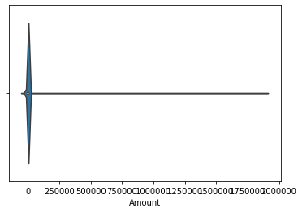

```python
# violin plot of amount
#px.violin(df, y = 'Amount')

sns.violinplot(df.Amount, bw=1)
```

### Feature 5: Vendors

```python
# count of Vendor
temp = df['Vendor'].value_counts()
temp[0:15]
```

```
STAPLES                      14842
AMAZON MKTPLACE PMTS         12197
WW GRAINGER                  12076
Amazon.com                   10766
BILL WARREN OFFICE PRODUC     4479
LOWES #00241                  4231
VWR INTERNATIONAL INC         3912
AT&T BILL PAYMENT             3064
AIRGAS CENTRAL                2682
AT&T DATA                     2622
WAL-MART #0137                2548
FASTENAL COMPANY01            2543
MCKESSON MEDICAL SUPPLY       2491
STAPLES       00105288        2137
WAL-MART #4241                2080
Name: Vendor, dtype: int64
```

### Feature 6: Transaction Date

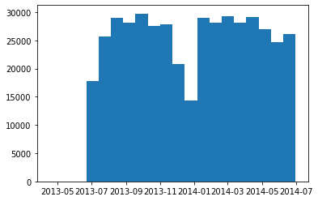

```python
# convert Transaction Date to date type and draw histogram
date = pd.to_datetime(df['Transaction Date'])
df['date'] = date
plt.hist(date, bins=20)
plt.show()
```

### Feature 7: MCC

```python
# count on Merchant Category Code (MCC)
temp = df['Merchant Category Code (MCC)'].value_counts()
temp[0:15]
```

```
STATIONERY, OFFICE SUPPLIES, PRINTING AND WRITING PAPER    24860
BOOK STORES                                                21981
INDUSTRIAL SUPPLIES NOT ELSEWHERE CLASSIFIED               21669
DENTAL/LABORATORY/MEDICAL/OPHTHALMIC HOSP EQIP AND SUP.    20183
GROCERY STORES,AND SUPERMARKETS                            17152
MISCELLANEOUS AND SPECIALTY RETAIL STORES                  13335
HOME SUPPLY WAREHOUSE STORES                               13254
AMERICAN AIRLINES                                          12015
TRAVEL AGENCIES                                            11777
TELECOMMUNICATION SERVICES                                 10358
BUSINESS SERVICES NOT ELSEWHERE CLASSIFIED                 10147
STATIONERY,OFFICE AND SCHOOL SUPPLY STORES                  9947
HARDWARE STORES                                             9031
GOVERNMENT SERVICES--NOT ELSEWHERE CLASSIFIED               8919
COURIER SERVICES-AIR AND GROUND,AND FREIGHT FORWARDERS      8234
Name: Merchant Category Code (MCC), dtype: int64
```

#### CheckPoint 2

- None of the columns has actual meanings by itself
- Among the columns, Agency Name, Vendor, Description, Amount, Transaction Date, and MCC show some patterns in their distribution, so they can be raw features
- Combination of columns may illustrate valuable hints, so aggregated features are tried next

## (2) Aggregated Features: Combine Certain Columns

```python
# set for more rows to display
pd.set_option('display.max_rows', 500)
```

### Feature 8: number_of_transaction_of_the_day

```python
# combine date, agency name, and cardholder, and count the transactions
df2 = df.groupby(['date', 'Agency Name', 'Cardholder Last Name', 'Cardholder First Initial']).agg({'Agency Number': 'count'})
df2.sort_values(by=['Agency Number'])
```

| date | Agency Name | Cardholder Last Name | Cardholder First Initial | Agency Number |
| --- | --- | --- | --- | --- |
| 2013-04-17 | OKLAHOMA STATE UNIVERSITY | Tucker | E | 1 |
| 2014-02-05 | OKLAHOMA STATE UNIVERSITY | Luckey | M | 1 |
|  |  | MORRIS | K | 1 |
|  |  | Mafi | J | 1 |
|  |  | Markum | R | 1 |
| ... | ... | ... | ... | ... |
| 2014-04-29 | UNIVERSITY OF OKLAHOMA | JOURNEY HOUSE TRAVEL INC | G | 105 |
| 2014-01-07 | UNIVERSITY OF OKLAHOMA | JOURNEY HOUSE TRAVEL INC | G | 121 |
| 2014-01-17 | UNIVERSITY OF OKLAHOMA | UNIVERSITY AMERICAN | G | 124 |
| 2013-12-20 | UNIVERSITY OF OKLAHOMA | JOURNEY HOUSE TRAVEL INC | G | 125 |
| 2014-01-10 | UNIVERSITY OF OKLAHOMA | JOURNEY HOUSE TRAVEL INC | G | 165 |

229382 rows × 1 columns

- it shows that certain cardholder has a large number of transacation a day, which may be a sign of fraud
- number_of_transaction_of_the_day is a useful feature

### Feature 9: amount_of_the_cardholder_of_the_day

```python
# combine date, agency name, and cardholder, and calculate sum of his or her transactions
df3 = df.groupby(['date', 'Agency Name', 'Cardholder Last Name', 'Cardholder First Initial']).agg({'Amount': 'sum'})
df3.sort_values(by=['Amount'])
```

| date | Agency Name | Cardholder Last Name | Cardholder First Initial | Amount |
| --- | --- | --- | --- | --- |
| 2014-03-20 | UNIVERSITY OF OKLAHOMA | MECHAM | S | -50459.00 |
| 2014-02-26 | OKLAHOMA MILITARY DEPARTMENT | MCCALL | L | -41550.22 |
| 2013-07-06 | OKLA. CAREER AND TECHNOLOGY EDUCATION | GOODNER | M | -38506.87 |
| 2014-02-14 | DEPARTMENT OF TRANSPORTATION | Lewis | G | -33623.34 |
| 2014-01-07 | UNIVERSITY OF OKLAHOMA | LARSON | B | -27864.00 |
| ... | ... | ... | ... | ... |
| 2013-10-03 | GRAND RIVER DAM AUTH. | Cardholder | e | 843183.92 |
| 2014-02-28 | GRAND RIVER DAM AUTH. | Cardholder | e | 902536.81 |
| 2013-10-25 | GRAND RIVER DAM AUTH. | Cardholder | e | 1184553.28 |
| 2013-07-19 | UNIV. OF OKLA. HEALTH SCIENCES CENTER | 77000 | 7 | 1750379.98 |
| 2013-08-21 | UNIV. OF OKLA. HEALTH SCIENCES CENTER | 77000 | 7 | 1903858.37 |

229382 rows × 1 columns

### Feature 10: mean_value_of_cardholer

```python
# combine date, agency name, and cardholder, and calculate the mean amount of his or her transactions
df4 = df.groupby(['Agency Name', 'Cardholder Last Name', 'Cardholder First Initial']).agg({'Amount': 'mean'})
df4.sort_values(by=['Amount'])
```

| Agency Name | Cardholder Last Name | Cardholder First Initial | Amount |
| --- | --- | --- | --- |
| UNIVERSITY OF OKLAHOMA | COTTS | C | -1394.880 |
| OKLAHOMA STATE UNIVERSITY | Dillwith | L | -214.170 |
| DEPARTMENT OF WILDLIFE CONSERVATION | Gregory | A | -195.500 |
| UNIVERSITY OF OKLAHOMA | GENTRY | J | -112.015 |
|  | HODGSON | S | -87.990 |
| ... | ... | ... | ... |
| OKLAHOMA MILITARY DEPARTMENT | STIERWALT | C | 21230.366 |
| UNIVERSITY OF OKLAHOMA | JOHNSON | L | 23290.342 |
| TULSA COMMUNITY COLLEGE | 75000 | 7 | 29873.610 |
| EMPLOYEES BENEFITS DEPARTMENT | 81500 | 8 | 171619.610 |
| UNIV. OF OKLA. HEALTH SCIENCES CENTER | 77000 | 7 | 609039.725 |

5571 rows × 1 columns

- the mean value of a cardholder's transactions could serve as a reference for the amount_of_the_cardholder_of_the_day

### Feature 11: cardholder_name

```python
cardholder_name = df.groupby(['Agency Name', 'Cardholder Last Name', 'Cardholder First Initial']).agg({'Agency Number': 'count'})
cardholder_name
```

| Agency Name | Cardholder Last Name | Cardholder First Initial | Agency Number |
| --- | --- | --- | --- |
| ARDMORE HIGHER EDUCATION CENTER | Pollard | C | 3 |
|  | Ray | M | 30 |
|  | Stoker | C | 26 |
| ATTORNEY GENERAL | Baustert | J | 40 |
|  | Brown | A | 74 |
| ... | ... | ... | ... |
| WORKERS COMPENSATION COURT | Eldred | M | 8 |
|  | Twyman | V | 3 |
| `DEPARTMENT OF EDUCATION | Bowman | I | 172 |
|  | Bryan | J | 199 |
|  | Ross | P | 553 |

5571 rows × 1 columns

### Feature 12: count_of_MCC_of_cardholder

```python
# count the MCC by each cardholder
df5 = df.groupby(['Agency Name', 'Cardholder Last Name', 'Cardholder First Initial', 'Merchant Category Code (MCC)']).agg({'Agency Number': 'count'})
df5.sort_values(by=['Agency Name', 'Cardholder Last Name'])
```

| Agency Name | Cardholder Last Name | Cardholder First Initial | Merchant Category Code (MCC) | Agency Number |
| --- | --- | --- | --- | --- |
| ARDMORE HIGHER EDUCATION CENTER | Pollard | C | COMPUTER NETWORK/INFORMATION SERVICES | 1 |
|  |  |  | MISCELLANEOUS AND SPECIALTY RETAIL STORES | 1 |
|  |  |  | SCHOOLS AND EDUCATIONAL SERVICES NOT ELSEWHERE CLASSIFIED | 1 |
|  | Ray | M | BUSINESS SERVICES NOT ELSEWHERE CLASSIFIED | 1 |
|  |  |  | CATALOG MERCHANTS | 7 |
| ... | ... | ... | ... | ... |
| `DEPARTMENT OF EDUCATION | Ross | P | ST. REGIS HOTEL | 1 |
|  |  |  | TRAVEL AGENCIES | 134 |
|  |  |  | TROPICANA RESORT AND CASINO | 1 |
|  |  |  | UNITED AIRLINES | 19 |
|  |  |  | WYNDHAM HOTELS | 6 |

70246 rows × 1 columns

- it shows some cardholders usually use the credit card for one or two categories of merchant, but for one or twice the card is used for other categories, which needs attention
- hence count_of_MCC_of_cardholder should be a feature

### Feature 13: count_of_vendor_of_cardholder

```python
# count Vendor by each cardholder
df6 = df.groupby(['Agency Name', 'Cardholder Last Name', 'Cardholder First Initial', 'Vendor']).agg({'Vendor': 'count'})
df6.sort_values(by=['Agency Name'])
```

| Agency Name | Cardholder Last Name | Cardholder First Initial | Vendor | Vendor |
| --- | --- | --- | --- | --- |
| ARDMORE HIGHER EDUCATION CENTER | Pollard | C | GODADDY.COM | 1 |
|  | Stoker | C | WYNDHAM GARDEN HOTEL | 1 |
|  |  |  | WHIRLPOOL CONSR PARTS | 4 |
|  |  |  | WAL-MART #0129 | 5 |
|  |  |  | STAPLES 00105510 | 2 |
| ... | ... | ... | ... | ... |
| `DEPARTMENT OF EDUCATION | Bryan | J | STAPLS3144609014001 | 1 |
|  |  |  | STAPLS3144609014000 | 1 |
|  |  |  | STAPLES | 47 |
|  |  |  | THOMPSONINFOSVCS | 1 |
|  | Ross | P | WYNDHAM GARDEN HOTEL | 6 |

168226 rows × 1 columns

- it shows that certain cardholder could have certain place (Vendor) for a card, so attention should be paid when some rare or foreign vendors appear

### Feature 14: sum_of_vendor_of_the_day

```python
# combine vendor, date, and cardholder, and calculate the sum of amount of his or her transactions
df7 = df.groupby(['date', 'Agency Name', 'Cardholder Last Name', 'Cardholder First Initial', 'Vendor']).agg({'Amount': 'sum'})
df7.sort_values(by=['Agency Name', 'Cardholder Last Name', 'Cardholder First Initial'])
```

| date | Agency Name | Cardholder Last Name | Cardholder First Initial | Vendor | Amount |
| --- | --- | --- | --- | --- | --- |
| 2013-09-10 | ARDMORE HIGHER EDUCATION CENTER | Pollard | C | PAYPAL WEBDESIGNCO | 345.00 |
| 2013-10-08 | ARDMORE HIGHER EDUCATION CENTER | Pollard | C | GODADDY.COM | 18.34 |
| 2013-10-30 | ARDMORE HIGHER EDUCATION CENTER | Pollard | C | SKC COMMUNICATION PRODUCT | 11.64 |
| 2013-06-27 | ARDMORE HIGHER EDUCATION CENTER | Ray | M | HOBBY-LOBBY #0113 | 101.63 |
| 2013-07-10 | ARDMORE HIGHER EDUCATION CENTER | Ray | M | HOBBY-LOBBY #0113 | 96.97 |
| ... | ... | ... | ... | ... | ... |
| 2014-01-27 | `DEPARTMENT OF EDUCATION | Ross | P | DAYS INN & SUITES | -77.40 |
| 2014-01-28 | `DEPARTMENT OF EDUCATION | Ross | P | AMERICAN AI 0017376713395 | 556.00 |
|  |  |  |  | AMERICAN AI 0017376713396 | 556.00 |
|  |  |  |  | JOURNYHSE JOHNSON | 25.00 |
|  |  |  |  | JOURNYHSE VASILEV | 25.00 |

368223 rows × 1 columns

- a sudden amount at an unfamilar vendor could be a sign for fraud

#### CheckPoint 3

- above combinations of columns are useful aggregated features for fraud detection
- Detailed Statistical Analysis on Description, Amount, and Transaction Date may be necessary, so periodic features are discussed next

## (3) Periodic Features: Statistical Analysis

### Feature 15: Q1_or_not

```python
# take a look at numeric columns first
df.describe()
```

|  | Agency Number | Amount |
| --- | --- | --- |
| count | 442458.000000 | 4.424580e+05 |
| mean | 42785.860353 | 4.249912e+02 |
| std | 33378.461293 | 5.266509e+03 |
| min | 1000.000000 | -4.286304e+04 |
| 25% | 1000.000000 | 3.091000e+01 |
| 50% | 47700.000000 | 1.048900e+02 |
| 75% | 76000.000000 | 3.450000e+02 |
| max | 98000.000000 | 1.903858e+06 |

### Feature 16: frequent_vendor

Fraud transactions usually have a small number of amount, so transactions with amount larger than 0 and smaller than mean value may be worth notice

From the value counts, following vendors have large numbers of transactions:  
STAPLES 14842  
AMAZON MKTPLACE PMTS 12197  
WW GRAINGER 12076  
Amazon.com 10766  
BILL WARREN OFFICE PRODUC 4479  
LOWES #00241 4231  
VWR INTERNATIONAL INC 3912  
AT&T BILL PAYMENT 3064  
AIRGAS CENTRAL 2682  
AT&T DATA 2622  
WAL-MART #0137 2548  
FASTENAL COMPANY01 2543  
MCKESSON MEDICAL SUPPLY 2491  
STAPLES 00105288 2137  
WAL-MART #4241 2080  
DMI DELL HIGHER EDUC 2029  
OKLA RESORTS PARKS & GOLF 2012  
SIGMA ALDRICH US 1664  
STAPLES DIRECT 1450  
EUREKA WATER COMPANY 1353  
These vendors should be categorized as frequent vendors, while others are not

```python
# label transactions as from frequent or infrequent vendors
df['frequent_vendor'] = 'FALSE'

df.loc[(df['Vendor'] == 'STAPLES'), 'frequent_vendor'] = 'TRUE'
df.loc[(df['Vendor'] == 'AMAZON MKTPLACE PMTS'), 'frequent_vendor'] = 'TRUE'
df.loc[(df['Vendor'] == 'Amazon.com'), 'frequent_vendor'] = 'TRUE'
df.loc[(df['Vendor'] == 'BILL WARREN OFFICE PRODUC'), 'frequent_vendor'] = 'TRUE'
df.loc[(df['Vendor'] == 'WW GRAINGER'), 'frequent_vendor'] = 'TRUE'
df.loc[(df['Vendor'] == 'LOWES #00241'), 'frequent_vendor'] = 'TRUE'
df.loc[(df['Vendor'] == 'VWR INTERNATIONAL INC'), 'frequent_vendor'] = 'TRUE'
df.loc[(df['Vendor'] == 'AT&T BILL PAYMENT'), 'frequent_vendor'] = 'TRUE'
df.loc[(df['Vendor'] == 'AIRGAS CENTRAL'), 'frequent_vendor'] = 'TRUE'
df.loc[(df['Vendor'] == 'AT&T DATA'), 'frequent_vendor'] = 'TRUE'
df.loc[(df['Vendor'] == 'FASTENAL COMPANY01'), 'frequent_vendor'] = 'TRUE'
df.loc[(df['Vendor'] == 'WAL-MART #0137'), 'frequent_vendor'] = 'TRUE'
df.loc[(df['Vendor'] == 'MCKESSON MEDICAL SUPPLY'), 'frequent_vendor'] = 'TRUE'
df.loc[(df['Vendor'] == 'STAPLES       00105288'), 'frequent_vendor'] = 'TRUE'
df.loc[(df['Vendor'] == 'WAL-MART #4241'), 'frequent_vendor'] = 'TRUE'
df.loc[(df['Vendor'] == 'DMI  DELL HIGHER EDUC'), 'frequent_vendor'] = 'TRUE'
df.loc[(df['Vendor'] == 'OKLA RESORTS PARKS & GOLF'), 'frequent_vendor'] = 'TRUE'
df.loc[(df['Vendor'] == 'SIGMA ALDRICH US'), 'frequent_vendor'] = 'TRUE'
df.loc[(df['Vendor'] == 'STAPLES DIRECT'), 'frequent_vendor'] = 'TRUE'
df.loc[(df['Vendor'] == 'EUREKA WATER COMPANY'), 'frequent_vendor'] = 'TRUE'
```

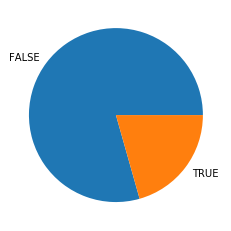

```python
# see the distribution of frequent_vendor
count2 = df['frequent_vendor'].value_counts()
df_count2 = pd.DataFrame(count2).reset_index()
df_count2.columns = ['frequent_vendor','Count']
# show the count with pie chart
plt.pie(df_count2['Count'], labels = df_count2['frequent_vendor'])
plt.show()
```

- the threshold of frequent or not may need further discussion

### Feature 17: frequent_cardholder

```python
# for now, cardholder with over 50 transactions in total are defined as frequent user
df7 = df.groupby(['Agency Name', 'Cardholder Last Name', 'Cardholder First Initial']).agg({'Agency Number': 'count'})
df7.drop(index = (df7.loc[df7['Agency Number']<50].index), inplace =True)
df7['frequent_user'] = 'TRUE'
df7
```

| Agency Name | Cardholder Last Name | Cardholder First Initial | Agency Number | frequent_user |
| --- | --- | --- | --- | --- |
| ATTORNEY GENERAL | Brown | A | 74 | TRUE |
|  | Dickenson | M | 716 | TRUE |
|  | PORTER | K | 82 | TRUE |
|  | Price | W | 149 | TRUE |
|  | Thompson | L | 190 | TRUE |
| ... | ... | ... | ... | ... |
| WATER RESOURCES BOARD | Williamson | L | 228 | TRUE |
|  | Yepez | S | 83 | TRUE |
| `DEPARTMENT OF EDUCATION | Bowman | I | 172 | TRUE |
|  | Bryan | J | 199 | TRUE |
|  | Ross | P | 553 | TRUE |

2166 rows × 2 columns

### Feature 18: frequent_MCC

```python
# for now, MCC with over 2000 transactions in total are defined as frequent MCC
df8 = df.groupby(['Merchant Category Code (MCC)']).agg({'Agency Number': 'count'})
df8.drop(index = (df8.loc[df8['Agency Number']<2000].index), inplace =True)
df8['frequent_MCC'] = 'TRUE'
```

```python
# merge df8 with df
df = pd.merge(df,df8,on=['Merchant Category Code (MCC)','Merchant Category Code (MCC)'], how='left')
df.drop(columns = ['Agency Number_y'])
df.loc[pd.isnull(df['frequent_MCC']) == True, 'frequent_MCC'] = 'FALSE'
```

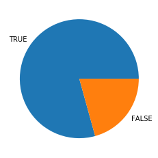

```python
# see the distribution of frequent_MCC
count3 = df['frequent_MCC'].value_counts()
df_count3 = pd.DataFrame(count3).reset_index()
df_count3.columns = ['frequent_MCC','Count']
# show the count with pie chart
plt.pie(df_count3['Count'], labels = df_count3['frequent_MCC'])
plt.show()
```

sometimes it may show some clue when the transaction is conducted on a weekday or not

### Feature 19: day_of_the_week

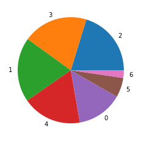

```python
# create a feature named day_of_the_week and visualize it with a pie chart
df['day_of_the_week'] = df['date'].dt.dayofweek

count4 = df['day_of_the_week'].value_counts()
df_count4 = pd.DataFrame(count4).reset_index()
df_count4.columns = ['day_of_the_week','Count']

plt.pie(df_count4['Count'], labels = df_count4['day_of_the_week'])
plt.show()
```

it can be inferred from the agency names that these transactions are usually for business, so transactions happpened on weekends may be abnormal

### Feature 20: holiday

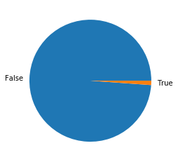

```python
# create a feature named holiday and visualize it with a pie chart
from pandas.tseries.holiday import USFederalHolidayCalendar as calendar
dr = pd.date_range(start='2010-01-01', end='2015-01-01')
cal = calendar()
holidays = cal.holidays(start=dr.min(), end=dr.max())
df['holiday'] = df['date'].isin(holidays)

count5 = df['holiday'].value_counts()
df_count5 = pd.DataFrame(count5).reset_index()
df_count5.columns = ['holiday','Count']

plt.pie(df_count5['Count'], labels = df_count5['holiday'])
plt.show()
```

similarly, transactions happened on holidays may be abnormal

### Feature 21: std_of_cardholder

```python
# calculate the standard error of amount of cardholders
df9 = df.groupby(['Agency Name', 'Cardholder Last Name', 'Cardholder First Initial']).agg({'Amount': 'std'})
df9.sort_values(by=['Amount'])
```

| Agency Name | Cardholder Last Name | Cardholder First Initial | Amount |
| --- | --- | --- | --- |
| UNIV. OF OKLA. HEALTH SCIENCES CENTER | COMP | P | 0.0 |
| UNIVERSITY OF OKLAHOMA | MYERS | V | 0.0 |
| UNIV.OF SCIENCE & ARTS OF OK | Shores | B | 0.0 |
| OKLAHOMA STATE UNIVERSITY | High | K | 0.0 |
| STATE AUDITOR AND INSPECTOR | Kirkes | D | 0.0 |
| ... | ... | ... | ... |
| UNIVERSITY OF OKLAHOMA | TRAXLER | T | NaN |
|  | TROY | C | NaN |
|  | VOELLER | R | NaN |
|  | WILSON | M | NaN |
| WORKER'S COMP. COMMISSION | Twyman | V | NaN |

5571 rows × 1 columns

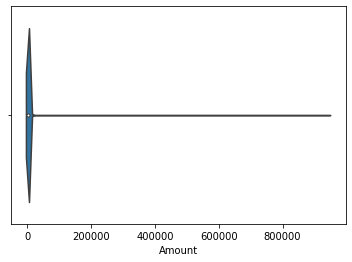

```python
# visualize the distribution of standard errors
std_of_cardholder = pd.Series(df9['Amount'])
sns.violinplot(std_of_cardholder)
```

## Summary of Features

According to the paper 'Feature engineering strategies for credit card fraud detection', features can be categorized as: raw, aggregated, extended aggregated and periodic.

Features mentioned and created above are concluded as:

- raw:
  1. Agency Name
  2. Vendor
  3. Description
  4. Amount
  5. Transaction Date
  6. Year-Month
  7. MCC
- aggregated:
  1. number_of_transaction_of_the_day: the number of transactions a cardholder conducted on a certain date
  2. amount_of_the_cardholder_of_the_day: the amount a cardholder spend on a certain date
  3. mean_value_of_cardholer: the mean value of a cardholder's transactions
  4. cardholder_name: Cardholder Last Name+Cardholder First Initial
  5. count_of_MCC_of_cardholder: the number of each MCC of which a certain cardholder has transactions
  6. count_of_vendor_of_cardholder: the number of each vendor of which a certain cardholder has transactions
  7. sum_of_vendor_of_the_day: the sum of amount a certain cardholder spend at a certain vendor
- periodic:
  1. Q1_or_not: if the amount of a transaction is lower than the 25% of amount of all transactions, Q1_or_not = True, otherwise Q1_or_not = False
  2. frequent_vendor: if the vendor of a transaction is defined as a frequent vendor, frequent_vendor = True, otherwise frequent_vendor = False
  3. frequent_cardholder: if a cardholder has more than 50 transactions in total, he or she is a frequent user, otherwise frequent_cardholder = False
  4. frequent_MCC: if a MCC has more than 2000 transactions in total, it is a frequent MCC, otherwise frequent_MCC = False
  5. day_of_the_week: on which day of the week the transaction happens, 0-6 represents Monday to Sunday
  6. holiday: if a transaction happens on a holiday, holiday = True, otherwise holiday = False
  7. std_of_cardholder: the standard error of amount of all transactions of a cardholder